# PROJECT-MOVIE_LENS

```python
#Import Required Data Analysis Libraries:
import numpy as np
import pandas as pd

#Import Plotting Libraries:
import matplotlib.pyplot as plt
import seaborn as sns
%matplotlib inline
```

```python
#help(pd.read_table)
```

```python
#Load the 3 datasets:
#1-movies Dataset:
movies_df = pd.read_csv(r'C:/Simplilearn-Data_Science/PROJECT-MOVIE_LENSE/Data-Science-with-Python-Project-One-master/Data science with Python 1/movies.dat',
                         sep='::',engine='python',names=['MovieID','Title','Genres'])
```

```python
#Print first few recrods:
movies_df.head(7)
```

|  | MovieID | Title | Genres |
| --- | --- | --- | --- |
| 0 | 1 | Toy Story (1995) | Animation\|Children's\|Comedy |
| 1 | 2 | Jumanji (1995) | Adventure\|Children's\|Fantasy |
| 2 | 3 | Grumpier Old Men (1995) | Comedy\|Romance |
| 3 | 4 | Waiting to Exhale (1995) | Comedy\|Drama |
| 4 | 5 | Father of the Bride Part II (1995) | Comedy |
| 5 | 6 | Heat (1995) | Action\|Crime\|Thriller |
| 6 | 7 | Sabrina (1995) | Comedy\|Romance |

```python
#Check shape of the dataframe:
movies_df.shape
```

```
(3883, 3)
```

```python
#By observing the above output of shape attribute we can say that we have 3883 unique movies in our dataset.
```

```python
#2:Ratings Dataset:
ratings_df = pd.read_csv(r'C:/Simplilearn-Data_Science/PROJECT-MOVIE_LENSE/Data-Science-with-Python-Project-One-master/Data science with Python 1/ratings.dat',
                        engine='python',sep='::',names=['UserID','MovieID','Rating','Timestamp'])
```

```python
#Print first few records:
ratings_df.head(7)
```

|  | UserID | MovieID | Rating | Timestamp |
| --- | --- | --- | --- | --- |
| 0 | 1 | 1193 | 5 | 978300760 |
| 1 | 1 | 661 | 3 | 978302109 |
| 2 | 1 | 914 | 3 | 978301968 |
| 3 | 1 | 3408 | 4 | 978300275 |
| 4 | 1 | 2355 | 5 | 978824291 |
| 5 | 1 | 1197 | 3 | 978302268 |
| 6 | 1 | 1287 | 5 | 978302039 |

```python
#Check shape of the dataframe:
ratings_df.shape
```

```
(1000209, 4)
```

```python
#Check unique value counts for each rating:
ratings_df['Rating'].value_counts()
```

```
4    348971
3    261197
5    226310
2    107557
1     56174
Name: Rating, dtype: int64
```

```python
#3:Users Dataset:
users_df = pd.read_csv(r'C:/Simplilearn-Data_Science/PROJECT-MOVIE_LENSE/Data-Science-with-Python-Project-One-master/Data science with Python 1/Users.dat',
                      engine='python',sep='::',names=['UserID','Gender','Age','Occupation','Zip-code'])
```

```python
#Print first few records:
users_df.head(7)
```

|  | UserID | Gender | Age | Occupation | Zip-code |
| --- | --- | --- | --- | --- | --- |
| 0 | 1 | F | 1 | 10 | 48067 |
| 1 | 2 | M | 56 | 16 | 70072 |
| 2 | 3 | M | 25 | 15 | 55117 |
| 3 | 4 | M | 45 | 7 | 02460 |
| 4 | 5 | M | 25 | 20 | 55455 |
| 5 | 6 | F | 50 | 9 | 55117 |
| 6 | 7 | M | 35 | 1 | 06810 |

```python
#Check Shape of the each dataframe:
print('Movies_Dataset:{}'.format(movies_df.shape))
print('Ratings_Dataset:{}'.format(ratings_df.shape))
print('Users_Dataset:{}'.format(users_df.shape))
```

```
Movies_Dataset:(3883, 3)
Ratings_Dataset:(1000209, 4)
Users_Dataset:(6040, 5)
```

```python
#help(pd.merge)
```

```python
#Merge two dataframes based on key='MovieID':
master_df_pre = pd.merge(movies_df,ratings_df,on='MovieID',how='inner')
```

```python
#Print first few records of new dataframe:
master_df_pre.head(10)
```

|  | MovieID | Title | Genres | UserID | Rating | Timestamp |
| --- | --- | --- | --- | --- | --- | --- |
| 0 | 1 | Toy Story (1995) | Animation\|Children's\|Comedy | 1 | 5 | 978824268 |
| 1 | 1 | Toy Story (1995) | Animation\|Children's\|Comedy | 6 | 4 | 978237008 |
| 2 | 1 | Toy Story (1995) | Animation\|Children's\|Comedy | 8 | 4 | 978233496 |
| 3 | 1 | Toy Story (1995) | Animation\|Children's\|Comedy | 9 | 5 | 978225952 |
| 4 | 1 | Toy Story (1995) | Animation\|Children's\|Comedy | 10 | 5 | 978226474 |
| 5 | 1 | Toy Story (1995) | Animation\|Children's\|Comedy | 18 | 4 | 978154768 |
| 6 | 1 | Toy Story (1995) | Animation\|Children's\|Comedy | 19 | 5 | 978555994 |
| 7 | 1 | Toy Story (1995) | Animation\|Children's\|Comedy | 21 | 3 | 978139347 |
| 8 | 1 | Toy Story (1995) | Animation\|Children's\|Comedy | 23 | 4 | 978463614 |
| 9 | 1 | Toy Story (1995) | Animation\|Children's\|Comedy | 26 | 3 | 978130703 |

```python
#Check shape of the new dataframe:
master_df_pre.shape
```

```
(1000209, 6)
```

```python
#Now,create "master dataframe" merging with previous dataframe on key='UserID':
master_df = pd.merge(master_df_pre,users_df,on='UserID',how='inner')
```

```python
#Check columns in master dataframe:
master_df.columns
```

```
Index(['MovieID', 'Title', 'Genres', 'UserID', 'Rating', 'Timestamp', 'Gender',
       'Age', 'Occupation', 'Zip-code'],
      dtype='object')
```

```python
master_df.head(7)
```

|  | MovieID | Title | Genres | UserID | Rating | Timestamp | Gender | Age | Occupation | Zip-code |
| --- | --- | --- | --- | --- | --- | --- | --- | --- | --- | --- |
| 0 | 1 | Toy Story (1995) | Animation\|Children's\|Comedy | 1 | 5 | 978824268 | F | 1 | 10 | 48067 |
| 1 | 48 | Pocahontas (1995) | Animation\|Children's\|Musical\|Romance | 1 | 5 | 978824351 | F | 1 | 10 | 48067 |
| 2 | 150 | Apollo 13 (1995) | Drama | 1 | 5 | 978301777 | F | 1 | 10 | 48067 |
| 3 | 260 | Star Wars: Episode IV - A New Hope (1977) | Action\|Adventure\|Fantasy\|Sci-Fi | 1 | 4 | 978300760 | F | 1 | 10 | 48067 |
| 4 | 527 | Schindler's List (1993) | Drama\|War | 1 | 5 | 978824195 | F | 1 | 10 | 48067 |
| 5 | 531 | Secret Garden, The (1993) | Children's\|Drama | 1 | 4 | 978302149 | F | 1 | 10 | 48067 |
| 6 | 588 | Aladdin (1992) | Animation\|Children's\|Comedy\|Musical | 1 | 4 | 978824268 | F | 1 | 10 | 48067 |

```python
master_df.shape
```

```
(1000209, 10)
```

```python
sample_genres_data_raw = master_df.Genres[:100000]
```

```python
type(sample_genres_data_raw)
```

```
pandas.core.series.Series
```

```python
len(sample_genres_data_raw)
```

```
100000
```

```python
sample_genres_data_raw_list = list(sample_genres_data_raw)
sample_genres_data_raw_list[:10]
```

```
["Animation|Children's|Comedy",
 "Animation|Children's|Musical|Romance",
 'Drama',
 'Action|Adventure|Fantasy|Sci-Fi',
 'Drama|War',
 "Children's|Drama",
 "Animation|Children's|Comedy|Musical",
 "Animation|Children's|Musical",
 "Animation|Children's|Musical",
 'Crime|Drama|Thriller']
```

```python
#Check type of the object:
type(sample_genres_data_raw_list)
```

```
list
```

```python
#Check length of the object:
len(sample_genres_data_raw_list)
```

```
100000
```

```python
#Experiment:
test = ["Animation|Children's|Comedy",
 "Animation|Children's|Musical|Romance",]
```

```python
"Animation|Children's|Comedy".split("|")
```

```
['Animation', "Children's", 'Comedy']
```

l1 = [1,2,3] l2 = [4,5,6]

```python
l1+l2
```

```
[1, 2, 3, 4, 5, 6]
```

```python
test_new = []
for i in range(len(test)):
    #test_new.append(test[i].split("|"))
    test_new += test[i].split("|")
```

```python
#Print test new:
test_new
```

```
['Animation',
 "Children's",
 'Comedy',
 'Animation',
 "Children's",
 'Musical',
 'Romance']
```

```python
#Check for Unique Genres categories:
genres = []
for i in range(len(sample_genres_data_raw_list)):
    genres = genres + sample_genres_data_raw_list[i].split("|")
#print("List of Genres:\n{}".format(genres))
unique_genres = list(set(genres))
print("\nList of Unique Genres:\n{}".format(unique_genres))
```

```
List of Unique Genres:
['Drama', 'Film-Noir', 'Comedy', 'Adventure', 'Mystery', 'Romance', 'Sci-Fi', 'Horror', 'Musical', 'Thriller', 'Action', 'Animation', 'Fantasy', 'Western', "Children's", 'Documentary', 'War', 'Crime']
```

```python
len(unique_genres)
```

```
18
```

#### As we can from the above output that there are **#18 unique** Genres Category in Dataset.

```python
#Converting list of unique genres into series:
unique_genres = pd.Series(unique_genres)
```

```python
#Print the Series:
unique_genres
```

```
0           Drama
1       Film-Noir
2          Comedy
3       Adventure
4         Mystery
5         Romance
6          Sci-Fi
7          Horror
8         Musical
9        Thriller
10         Action
11      Animation
12        Fantasy
13        Western
14     Children's
15    Documentary
16            War
17          Crime
dtype: object
```

```python
type(unique_genres)
```

```
pandas.core.series.Series
```

```python
sample_data = master_df[:100000]
```

```python
type(sample_data)
```

```
pandas.core.frame.DataFrame
```

```python
sample_data[:3]
```

|  | MovieID | Title | Genres | UserID | Rating | Timestamp | Gender | Age | Occupation | Zip-code |
| --- | --- | --- | --- | --- | --- | --- | --- | --- | --- | --- |
| 0 | 1 | Toy Story (1995) | Animation\|Children's\|Comedy | 1 | 5 | 978824268 | F | 1 | 10 | 48067 |
| 1 | 48 | Pocahontas (1995) | Animation\|Children's\|Musical\|Romance | 1 | 5 | 978824351 | F | 1 | 10 | 48067 |
| 2 | 150 | Apollo 13 (1995) | Drama | 1 | 5 | 978301777 | F | 1 | 10 | 48067 |

```python
#Create a new Dataframe with unique value for each category:
genres_df = pd.DataFrame()
for row in sample_data.Genres:
    genres_val = unique_genres.isin(row.split("|"))
    genres_df = genres_df.append(genres_val,ignore_index=True)
genres_df.head()
```

|  | 0 | 1 | 2 | 3 | 4 | 5 | 6 | 7 | 8 | 9 | 10 | 11 | 12 | 13 | 14 | 15 | 16 | 17 |
| --- | --- | --- | --- | --- | --- | --- | --- | --- | --- | --- | --- | --- | --- | --- | --- | --- | --- | --- |
| 0 | 0.0 | 0.0 | 1.0 | 0.0 | 0.0 | 0.0 | 0.0 | 0.0 | 0.0 | 0.0 | 0.0 | 1.0 | 0.0 | 0.0 | 1.0 | 0.0 | 0.0 | 0.0 |
| 1 | 0.0 | 0.0 | 0.0 | 0.0 | 0.0 | 1.0 | 0.0 | 0.0 | 1.0 | 0.0 | 0.0 | 1.0 | 0.0 | 0.0 | 1.0 | 0.0 | 0.0 | 0.0 |
| 2 | 1.0 | 0.0 | 0.0 | 0.0 | 0.0 | 0.0 | 0.0 | 0.0 | 0.0 | 0.0 | 0.0 | 0.0 | 0.0 | 0.0 | 0.0 | 0.0 | 0.0 | 0.0 |
| 3 | 0.0 | 0.0 | 0.0 | 1.0 | 0.0 | 0.0 | 1.0 | 0.0 | 0.0 | 0.0 | 1.0 | 0.0 | 1.0 | 0.0 | 0.0 | 0.0 | 0.0 | 0.0 |
| 4 | 1.0 | 0.0 | 0.0 | 0.0 | 0.0 | 0.0 | 0.0 | 0.0 | 0.0 | 0.0 | 0.0 | 0.0 | 0.0 | 0.0 | 0.0 | 0.0 | 1.0 | 0.0 |

```python
genres_df.columns = unique_genres
```

```python
#Check shape of genres_df:
genres_df.shape
```

```
(100000, 18)
```

```python
genres_df.head()
```

|  | Drama | Film-Noir | Comedy | Adventure | Mystery | Romance | Sci-Fi | Horror | Musical | Thriller | Action | Animation | Fantasy | Western | Children's | Documentary | War | Crime |
| --- | --- | --- | --- | --- | --- | --- | --- | --- | --- | --- | --- | --- | --- | --- | --- | --- | --- | --- |
| 0 | 0.0 | 0.0 | 1.0 | 0.0 | 0.0 | 0.0 | 0.0 | 0.0 | 0.0 | 0.0 | 0.0 | 1.0 | 0.0 | 0.0 | 1.0 | 0.0 | 0.0 | 0.0 |
| 1 | 0.0 | 0.0 | 0.0 | 0.0 | 0.0 | 1.0 | 0.0 | 0.0 | 1.0 | 0.0 | 0.0 | 1.0 | 0.0 | 0.0 | 1.0 | 0.0 | 0.0 | 0.0 |
| 2 | 1.0 | 0.0 | 0.0 | 0.0 | 0.0 | 0.0 | 0.0 | 0.0 | 0.0 | 0.0 | 0.0 | 0.0 | 0.0 | 0.0 | 0.0 | 0.0 | 0.0 | 0.0 |
| 3 | 0.0 | 0.0 | 0.0 | 1.0 | 0.0 | 0.0 | 1.0 | 0.0 | 0.0 | 0.0 | 1.0 | 0.0 | 1.0 | 0.0 | 0.0 | 0.0 | 0.0 | 0.0 |
| 4 | 1.0 | 0.0 | 0.0 | 0.0 | 0.0 | 0.0 | 0.0 | 0.0 | 0.0 | 0.0 | 0.0 | 0.0 | 0.0 | 0.0 | 0.0 | 0.0 | 1.0 | 0.0 |

```python
#Check some records from master dataframe:
master_df.head(7)
```

|  | MovieID | Title | Genres | UserID | Rating | Timestamp | Gender | Age | Occupation | Zip-code |
| --- | --- | --- | --- | --- | --- | --- | --- | --- | --- | --- |
| 0 | 1 | Toy Story (1995) | Animation\|Children's\|Comedy | 1 | 5 | 978824268 | F | 1 | 10 | 48067 |
| 1 | 48 | Pocahontas (1995) | Animation\|Children's\|Musical\|Romance | 1 | 5 | 978824351 | F | 1 | 10 | 48067 |
| 2 | 150 | Apollo 13 (1995) | Drama | 1 | 5 | 978301777 | F | 1 | 10 | 48067 |
| 3 | 260 | Star Wars: Episode IV - A New Hope (1977) | Action\|Adventure\|Fantasy\|Sci-Fi | 1 | 4 | 978300760 | F | 1 | 10 | 48067 |
| 4 | 527 | Schindler's List (1993) | Drama\|War | 1 | 5 | 978824195 | F | 1 | 10 | 48067 |
| 5 | 531 | Secret Garden, The (1993) | Children's\|Drama | 1 | 4 | 978302149 | F | 1 | 10 | 48067 |
| 6 | 588 | Aladdin (1992) | Animation\|Children's\|Comedy\|Musical | 1 | 4 | 978824268 | F | 1 | 10 | 48067 |

```python
#Concatanating this Master df and Genres df:
#Take 100000 samples from Master df and concat it with genres df:
sample_master_df = master_df[:100000]
```

```python
#View first few records from sample_master_df:
sample_master_df.head(10)
```

|  | MovieID | Title | Genres | UserID | Rating | Timestamp | Gender | Age | Occupation | Zip-code |
| --- | --- | --- | --- | --- | --- | --- | --- | --- | --- | --- |
| 0 | 1 | Toy Story (1995) | Animation\|Children's\|Comedy | 1 | 5 | 978824268 | F | 1 | 10 | 48067 |
| 1 | 48 | Pocahontas (1995) | Animation\|Children's\|Musical\|Romance | 1 | 5 | 978824351 | F | 1 | 10 | 48067 |
| 2 | 150 | Apollo 13 (1995) | Drama | 1 | 5 | 978301777 | F | 1 | 10 | 48067 |
| 3 | 260 | Star Wars: Episode IV - A New Hope (1977) | Action\|Adventure\|Fantasy\|Sci-Fi | 1 | 4 | 978300760 | F | 1 | 10 | 48067 |
| 4 | 527 | Schindler's List (1993) | Drama\|War | 1 | 5 | 978824195 | F | 1 | 10 | 48067 |
| 5 | 531 | Secret Garden, The (1993) | Children's\|Drama | 1 | 4 | 978302149 | F | 1 | 10 | 48067 |
| 6 | 588 | Aladdin (1992) | Animation\|Children's\|Comedy\|Musical | 1 | 4 | 978824268 | F | 1 | 10 | 48067 |
| 7 | 594 | Snow White and the Seven Dwarfs (1937) | Animation\|Children's\|Musical | 1 | 4 | 978302268 | F | 1 | 10 | 48067 |
| 8 | 595 | Beauty and the Beast (1991) | Animation\|Children's\|Musical | 1 | 5 | 978824268 | F | 1 | 10 | 48067 |
| 9 | 608 | Fargo (1996) | Crime\|Drama\|Thriller | 1 | 4 | 978301398 | F | 1 | 10 | 48067 |

```python
#Check shape of sample_master_df:
sample_master_df.shape
```

```
(100000, 10)
```

```python
#Check shape of genres_df:
genres_df.shape
```

```
(100000, 18)
```

```python
sample_master_df = pd.concat([sample_master_df,genres_df],axis=1)
```

```python
#Check first few records:
sample_master_df.head(7)
```

|  | MovieID | Title | Genres | UserID | Rating | Timestamp | Gender | Age | Occupation | Zip-code | ... | Musical | Thriller | Action | Animation | Fantasy | Western | Children's | Documentary | War | Crime |
| --- | --- | --- | --- | --- | --- | --- | --- | --- | --- | --- | --- | --- | --- | --- | --- | --- | --- | --- | --- | --- | --- |
| 0 | 1 | Toy Story (1995) | Animation\|Children's\|Comedy | 1 | 5 | 978824268 | F | 1 | 10 | 48067 | ... | 0.0 | 0.0 | 0.0 | 1.0 | 0.0 | 0.0 | 1.0 | 0.0 | 0.0 | 0.0 |
| 1 | 48 | Pocahontas (1995) | Animation\|Children's\|Musical\|Romance | 1 | 5 | 978824351 | F | 1 | 10 | 48067 | ... | 1.0 | 0.0 | 0.0 | 1.0 | 0.0 | 0.0 | 1.0 | 0.0 | 0.0 | 0.0 |
| 2 | 150 | Apollo 13 (1995) | Drama | 1 | 5 | 978301777 | F | 1 | 10 | 48067 | ... | 0.0 | 0.0 | 0.0 | 0.0 | 0.0 | 0.0 | 0.0 | 0.0 | 0.0 | 0.0 |
| 3 | 260 | Star Wars: Episode IV - A New Hope (1977) | Action\|Adventure\|Fantasy\|Sci-Fi | 1 | 4 | 978300760 | F | 1 | 10 | 48067 | ... | 0.0 | 0.0 | 1.0 | 0.0 | 1.0 | 0.0 | 0.0 | 0.0 | 0.0 | 0.0 |
| 4 | 527 | Schindler's List (1993) | Drama\|War | 1 | 5 | 978824195 | F | 1 | 10 | 48067 | ... | 0.0 | 0.0 | 0.0 | 0.0 | 0.0 | 0.0 | 0.0 | 0.0 | 1.0 | 0.0 |
| 5 | 531 | Secret Garden, The (1993) | Children's\|Drama | 1 | 4 | 978302149 | F | 1 | 10 | 48067 | ... | 0.0 | 0.0 | 0.0 | 0.0 | 0.0 | 0.0 | 1.0 | 0.0 | 0.0 | 0.0 |
| 6 | 588 | Aladdin (1992) | Animation\|Children's\|Comedy\|Musical | 1 | 4 | 978824268 | F | 1 | 10 | 48067 | ... | 1.0 | 0.0 | 0.0 | 1.0 | 0.0 | 0.0 | 1.0 | 0.0 | 0.0 | 0.0 |

7 rows × 28 columns

```python
#Check shape of the sample_master_df:
sample_master_df.shape
```

```
(100000, 28)
```

```python
#Check columns from the dataframe:
sample_master_df.columns
```

```
Index(['MovieID', 'Title', 'Genres', 'UserID', 'Rating', 'Timestamp', 'Gender',
       'Age', 'Occupation', 'Zip-code', 'Drama', 'Film-Noir', 'Comedy',
       'Adventure', 'Mystery', 'Romance', 'Sci-Fi', 'Horror', 'Musical',
       'Thriller', 'Action', 'Animation', 'Fantasy', 'Western', 'Children's',
       'Documentary', 'War', 'Crime'],
      dtype='object')
```

```python
#Dropping Genres column:
sample_master_df.drop(['Genres'],axis=1,inplace=True)
```

```python
#Check shape again:
sample_master_df.shape
```

```
(100000, 27)
```

```python
#Check columns again:
sample_master_df.columns
```

```
Index(['MovieID', 'Title', 'UserID', 'Rating', 'Timestamp', 'Gender', 'Age',
       'Occupation', 'Zip-code', 'Drama', 'Film-Noir', 'Comedy', 'Adventure',
       'Mystery', 'Romance', 'Sci-Fi', 'Horror', 'Musical', 'Thriller',
       'Action', 'Animation', 'Fantasy', 'Western', 'Children's',
       'Documentary', 'War', 'Crime'],
      dtype='object')
```

```python
#Print first few records:
sample_master_df.head()
```

|  | MovieID | Title | UserID | Rating | Timestamp | Gender | Age | Occupation | Zip-code | Drama | ... | Musical | Thriller | Action | Animation | Fantasy | Western | Children's | Documentary | War | Crime |
| --- | --- | --- | --- | --- | --- | --- | --- | --- | --- | --- | --- | --- | --- | --- | --- | --- | --- | --- | --- | --- | --- |
| 0 | 1 | Toy Story (1995) | 1 | 5 | 978824268 | F | 1 | 10 | 48067 | 0.0 | ... | 0.0 | 0.0 | 0.0 | 1.0 | 0.0 | 0.0 | 1.0 | 0.0 | 0.0 | 0.0 |
| 1 | 48 | Pocahontas (1995) | 1 | 5 | 978824351 | F | 1 | 10 | 48067 | 0.0 | ... | 1.0 | 0.0 | 0.0 | 1.0 | 0.0 | 0.0 | 1.0 | 0.0 | 0.0 | 0.0 |
| 2 | 150 | Apollo 13 (1995) | 1 | 5 | 978301777 | F | 1 | 10 | 48067 | 1.0 | ... | 0.0 | 0.0 | 0.0 | 0.0 | 0.0 | 0.0 | 0.0 | 0.0 | 0.0 | 0.0 |
| 3 | 260 | Star Wars: Episode IV - A New Hope (1977) | 1 | 4 | 978300760 | F | 1 | 10 | 48067 | 0.0 | ... | 0.0 | 0.0 | 1.0 | 0.0 | 1.0 | 0.0 | 0.0 | 0.0 | 0.0 | 0.0 |
| 4 | 527 | Schindler's List (1993) | 1 | 5 | 978824195 | F | 1 | 10 | 48067 | 1.0 | ... | 0.0 | 0.0 | 0.0 | 0.0 | 0.0 | 0.0 | 0.0 | 0.0 | 1.0 | 0.0 |

5 rows × 27 columns

```python
#Check any null value present in the dataset:
sample_master_df.isnull().sum()
```

```
MovieID        0
Title          0
UserID         0
Rating         0
Timestamp      0
Gender         0
Age            0
Occupation     0
Zip-code       0
Drama          0
Film-Noir      0
Comedy         0
Adventure      0
Mystery        0
Romance        0
Sci-Fi         0
Horror         0
Musical        0
Thriller       0
Action         0
Animation      0
Fantasy        0
Western        0
Children's     0
Documentary    0
War            0
Crime          0
dtype: int64
```

```python
#Checking Dtype of all the columns:
sample_master_df.dtypes
```

```
MovieID          int64
Title           object
UserID           int64
Rating           int64
Timestamp        int64
Gender          object
Age              int64
Occupation       int64
Zip-code        object
Drama          float64
Film-Noir      float64
Comedy         float64
Adventure      float64
Mystery        float64
Romance        float64
Sci-Fi         float64
Horror         float64
Musical        float64
Thriller       float64
Action         float64
Animation      float64
Fantasy        float64
Western        float64
Children's     float64
Documentary    float64
War            float64
Crime          float64
dtype: object
```

### Treatment for Gender column(as it is Categorial in nature)

```python
sample_master_df['Gender'].value_counts()
```

```
M    75683
F    24317
Name: Gender, dtype: int64
```

```python
sample_master_df['Gender'] = np.where(sample_master_df['Gender']=='M',1,sample_master_df['Gender'])
sample_master_df['Gender'] = np.where(sample_master_df['Gender']=='F',0,sample_master_df['Gender'])
```

```python
#Check value counts again for confirmation:
sample_master_df['Gender'].value_counts()
```

```
1    75683
0    24317
Name: Gender, dtype: int64
```

```python
#Changing Dtype:
sample_master_df['Gender'] = sample_master_df['Gender'].astype('int64')
```

### Check 'dtypes' again:

```python
sample_master_df.dtypes
```

```
MovieID          int64
Title           object
UserID           int64
Rating           int64
Timestamp        int64
Gender           int64
Age              int64
Occupation       int64
Zip-code        object
Drama          float64
Film-Noir      float64
Comedy         float64
Adventure      float64
Mystery        float64
Romance        float64
Sci-Fi         float64
Horror         float64
Musical        float64
Thriller       float64
Action         float64
Animation      float64
Fantasy        float64
Western        float64
Children's     float64
Documentary    float64
War            float64
Crime          float64
dtype: object
```

```python
sample_master_df[20:30]
```

|  | MovieID | Title | UserID | Rating | Timestamp | Gender | Age | Occupation | Zip-code | Drama | ... | Musical | Thriller | Action | Animation | Fantasy | Western | Children's | Documentary | War | Crime |
| --- | --- | --- | --- | --- | --- | --- | --- | --- | --- | --- | --- | --- | --- | --- | --- | --- | --- | --- | --- | --- | --- |
| 20 | 1035 | Sound of Music, The (1965) | 1 | 5 | 978301753 | 0 | 1 | 10 | 48067 | 0.0 | ... | 1.0 | 0.0 | 0.0 | 0.0 | 0.0 | 0.0 | 0.0 | 0.0 | 0.0 | 0.0 |
| 21 | 1097 | E.T. the Extra-Terrestrial (1982) | 1 | 4 | 978301953 | 0 | 1 | 10 | 48067 | 1.0 | ... | 0.0 | 0.0 | 0.0 | 0.0 | 1.0 | 0.0 | 1.0 | 0.0 | 0.0 | 0.0 |
| 22 | 1193 | One Flew Over the Cuckoo's Nest (1975) | 1 | 5 | 978300760 | 0 | 1 | 10 | 48067 | 1.0 | ... | 0.0 | 0.0 | 0.0 | 0.0 | 0.0 | 0.0 | 0.0 | 0.0 | 0.0 | 0.0 |
| 23 | 1197 | Princess Bride, The (1987) | 1 | 3 | 978302268 | 0 | 1 | 10 | 48067 | 0.0 | ... | 0.0 | 0.0 | 1.0 | 0.0 | 0.0 | 0.0 | 0.0 | 0.0 | 0.0 | 0.0 |
| 24 | 1207 | To Kill a Mockingbird (1962) | 1 | 4 | 978300719 | 0 | 1 | 10 | 48067 | 1.0 | ... | 0.0 | 0.0 | 0.0 | 0.0 | 0.0 | 0.0 | 0.0 | 0.0 | 0.0 | 0.0 |
| 25 | 1246 | Dead Poets Society (1989) | 1 | 4 | 978302091 | 0 | 1 | 10 | 48067 | 1.0 | ... | 0.0 | 0.0 | 0.0 | 0.0 | 0.0 | 0.0 | 0.0 | 0.0 | 0.0 | 0.0 |
| 26 | 1270 | Back to the Future (1985) | 1 | 5 | 978300055 | 0 | 1 | 10 | 48067 | 0.0 | ... | 0.0 | 0.0 | 0.0 | 0.0 | 0.0 | 0.0 | 0.0 | 0.0 | 0.0 | 0.0 |
| 27 | 1287 | Ben-Hur (1959) | 1 | 5 | 978302039 | 0 | 1 | 10 | 48067 | 1.0 | ... | 0.0 | 0.0 | 1.0 | 0.0 | 0.0 | 0.0 | 0.0 | 0.0 | 0.0 | 0.0 |
| 28 | 1545 | Ponette (1996) | 1 | 4 | 978824139 | 0 | 1 | 10 | 48067 | 1.0 | ... | 0.0 | 0.0 | 0.0 | 0.0 | 0.0 | 0.0 | 0.0 | 0.0 | 0.0 | 0.0 |
| 29 | 1566 | Hercules (1997) | 1 | 4 | 978824330 | 0 | 1 | 10 | 48067 | 0.0 | ... | 1.0 | 0.0 | 0.0 | 1.0 | 0.0 | 0.0 | 1.0 | 0.0 | 0.0 | 0.0 |

10 rows × 27 columns

### DATA EXPLORATION:

#### Q-1: User Age Distribution--

- Using Histogram:

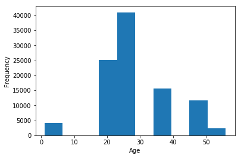

```python
#User Age Distribution:
sample_master_df.Age.plot(kind='hist')
plt.xlabel("Age")
plt.show()
```

- Using KDE plot:

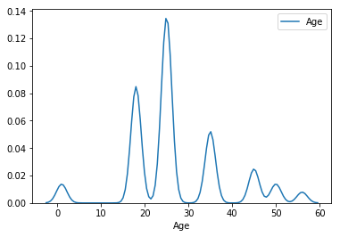

```python
sns.kdeplot(sample_master_df.Age)
plt.xlabel("Age")
plt.show()
```

### Visualization of Overall ratings by the user:

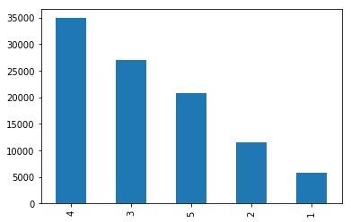

```python
sample_master_df['Rating'].value_counts().plot(kind='bar')
plt.show()
```

### User Ratings for the 'Toy-Story' movie:

```python
group = sample_master_df.groupby('Title')
```

```python
toy_story_data = group.get_group('Toy Story (1995)')
```

Getting total count of **ratings**:

```python
toy_story_data.Rating.count()
```

```
378
```

Getting count for **each rating**:

```python
toy_story_data.Rating.value_counts()
```

```
4    153
5    150
3     64
2     11
Name: Rating, dtype: int64
```

Visualize using **Bar plot**:

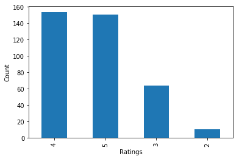

```python
toy_story_data.Rating.value_counts().plot(kind='bar')
plt.xlabel("Ratings")
plt.ylabel("Count")
plt.show()
```

### Finding the rating data by perticular UserID:

- Taken UserID = 889

```python
sample_master_df.loc[sample_master_df['UserID']==889,["UserID","Rating"]]
```

|  | UserID | Rating |
| --- | --- | --- |
| 79453 | 889 | 4 |
| 79454 | 889 | 2 |
| 79455 | 889 | 2 |
| 79456 | 889 | 3 |
| 79457 | 889 | 1 |
| 79458 | 889 | 2 |
| 79459 | 889 | 3 |
| 79460 | 889 | 5 |
| 79461 | 889 | 3 |
| 79462 | 889 | 4 |
| 79463 | 889 | 5 |
| 79464 | 889 | 4 |
| 79465 | 889 | 2 |
| 79466 | 889 | 4 |
| 79467 | 889 | 2 |
| 79468 | 889 | 4 |
| 79469 | 889 | 4 |
| 79470 | 889 | 3 |
| 79471 | 889 | 3 |
| 79472 | 889 | 3 |
| 79473 | 889 | 2 |
| 79474 | 889 | 2 |
| 79475 | 889 | 3 |
| 79476 | 889 | 2 |
| 79477 | 889 | 2 |
| 79478 | 889 | 2 |
| 79479 | 889 | 2 |
| 79480 | 889 | 1 |
| 79481 | 889 | 2 |
| 79482 | 889 | 3 |
| ... | ... | ... |
| 80941 | 889 | 4 |
| 80942 | 889 | 3 |
| 80943 | 889 | 2 |
| 80944 | 889 | 2 |
| 80945 | 889 | 4 |
| 80946 | 889 | 2 |
| 80947 | 889 | 3 |
| 80948 | 889 | 3 |
| 80949 | 889 | 2 |
| 80950 | 889 | 1 |
| 80951 | 889 | 3 |
| 80952 | 889 | 3 |
| 80953 | 889 | 3 |
| 80954 | 889 | 3 |
| 80955 | 889 | 3 |
| 80956 | 889 | 3 |
| 80957 | 889 | 3 |
| 80958 | 889 | 2 |
| 80959 | 889 | 3 |
| 80960 | 889 | 3 |
| 80961 | 889 | 3 |
| 80962 | 889 | 3 |
| 80963 | 889 | 2 |
| 80964 | 889 | 2 |
| 80965 | 889 | 1 |
| 80966 | 889 | 3 |
| 80967 | 889 | 3 |
| 80968 | 889 | 2 |
| 80969 | 889 | 1 |
| 80970 | 889 | 2 |

1518 rows × 2 columns

```python
userIDgrp = sample_master_df.groupby("UserID")
```

```python
userID889_data = userIDgrp.get_group(889)
```

Getting **Total count** of all ratings:

```python
userID889_data.Rating.count()
```

```
1518
```

Getting count of **each unique** rating:

```python
userID889_data.Rating.value_counts()
```

```
3    579
2    452
4    272
1    123
5     92
Name: Rating, dtype: int64
```

Visualize the Ratings data:

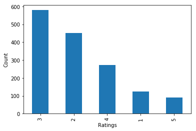

```python
userID889_data.Rating.value_counts().plot(kind='bar')
plt.xlabel("Ratings")
plt.ylabel("Count")
plt.show()
```

### Top 25 movies by viewership rating:

- **First 25** Movies by viewership rating:

```python
sample_master_df.loc[sample_master_df['Rating']==5,["Title","Rating"]].head(25)
```

|  | Title | Rating |
| --- | --- | --- |
| 0 | Toy Story (1995) | 5 |
| 1 | Pocahontas (1995) | 5 |
| 2 | Apollo 13 (1995) | 5 |
| 4 | Schindler's List (1993) | 5 |
| 8 | Beauty and the Beast (1991) | 5 |
| 17 | Cinderella (1950) | 5 |
| 18 | Mary Poppins (1964) | 5 |
| 19 | Dumbo (1941) | 5 |
| 20 | Sound of Music, The (1965) | 5 |
| 22 | One Flew Over the Cuckoo's Nest (1975) | 5 |
| 26 | Back to the Future (1985) | 5 |
| 27 | Ben-Hur (1959) | 5 |
| 31 | Last Days of Disco, The (1998) | 5 |
| 33 | Rain Man (1988) | 5 |
| 36 | Saving Private Ryan (1998) | 5 |
| 40 | Bug's Life, A (1998) | 5 |
| 47 | Christmas Story, A (1983) | 5 |
| 49 | Awakenings (1990) | 5 |
| 56 | Pocahontas (1995) | 5 |
| 57 | Umbrellas of Cherbourg, The (Parapluies de Che... | 5 |
| 68 | Pretty Woman (1990) | 5 |
| 71 | My Fair Lady (1964) | 5 |
| 76 | Sound of Music, The (1965) | 5 |
| 78 | Dirty Dancing (1987) | 5 |
| 83 | Grease (1978) | 5 |

- **Last 25** Movies by viewership rating:

```python
sample_master_df.loc[sample_master_df['Rating']==5,["Title","Rating"]].tail(25)
```

|  | Title | Rating |
| --- | --- | --- |
| 99750 | Wonder Boys (2000) | 5 |
| 99764 | Almost Famous (2000) | 5 |
| 99778 | Clerks (1994) | 5 |
| 99783 | Shawshank Redemption, The (1994) | 5 |
| 99812 | Rock, The (1996) | 5 |
| 99822 | Swingers (1996) | 5 |
| 99825 | Star Wars: Episode V - The Empire Strikes Back... | 5 |
| 99826 | Raiders of the Lost Ark (1981) | 5 |
| 99831 | Indiana Jones and the Last Crusade (1989) | 5 |
| 99836 | Beavis and Butt-head Do America (1996) | 5 |
| 99843 | Austin Powers: International Man of Mystery (1... | 5 |
| 99851 | L.A. Confidential (1997) | 5 |
| 99859 | Wedding Singer, The (1998) | 5 |
| 99863 | Perfect Murder, A (1998) | 5 |
| 99864 | There's Something About Mary (1998) | 5 |
| 99874 | My Cousin Vinny (1992) | 5 |
| 99878 | Payback (1999) | 5 |
| 99885 | South Park: Bigger, Longer and Uncut (1999) | 5 |
| 99891 | American Beauty (1999) | 5 |
| 99897 | Being John Malkovich (1999) | 5 |
| 99900 | Dogma (1999) | 5 |
| 99903 | Cider House Rules, The (1999) | 5 |
| 99908 | Wayne's World (1992) | 5 |
| 99924 | Keeping the Faith (2000) | 5 |
| 99964 | Ed Wood (1994) | 5 |

#### Using 'nlargest' function:

- It's drawback is that it's giving all the columns.

```python
sample_master_df.nlargest(25,'Rating')
```

|  | MovieID | Title | UserID | Rating | Timestamp | Gender | Age | Occupation | Zip-code | Drama | ... | Musical | Thriller | Action | Animation | Fantasy | Western | Children's | Documentary | War | Crime |
| --- | --- | --- | --- | --- | --- | --- | --- | --- | --- | --- | --- | --- | --- | --- | --- | --- | --- | --- | --- | --- | --- |
| 0 | 1 | Toy Story (1995) | 1 | 5 | 978824268 | 0 | 1 | 10 | 48067 | 0.0 | ... | 0.0 | 0.0 | 0.0 | 1.0 | 0.0 | 0.0 | 1.0 | 0.0 | 0.0 | 0.0 |
| 1 | 48 | Pocahontas (1995) | 1 | 5 | 978824351 | 0 | 1 | 10 | 48067 | 0.0 | ... | 1.0 | 0.0 | 0.0 | 1.0 | 0.0 | 0.0 | 1.0 | 0.0 | 0.0 | 0.0 |
| 2 | 150 | Apollo 13 (1995) | 1 | 5 | 978301777 | 0 | 1 | 10 | 48067 | 1.0 | ... | 0.0 | 0.0 | 0.0 | 0.0 | 0.0 | 0.0 | 0.0 | 0.0 | 0.0 | 0.0 |
| 4 | 527 | Schindler's List (1993) | 1 | 5 | 978824195 | 0 | 1 | 10 | 48067 | 1.0 | ... | 0.0 | 0.0 | 0.0 | 0.0 | 0.0 | 0.0 | 0.0 | 0.0 | 1.0 | 0.0 |
| 8 | 595 | Beauty and the Beast (1991) | 1 | 5 | 978824268 | 0 | 1 | 10 | 48067 | 0.0 | ... | 1.0 | 0.0 | 0.0 | 1.0 | 0.0 | 0.0 | 1.0 | 0.0 | 0.0 | 0.0 |
| 17 | 1022 | Cinderella (1950) | 1 | 5 | 978300055 | 0 | 1 | 10 | 48067 | 0.0 | ... | 1.0 | 0.0 | 0.0 | 1.0 | 0.0 | 0.0 | 1.0 | 0.0 | 0.0 | 0.0 |
| 18 | 1028 | Mary Poppins (1964) | 1 | 5 | 978301777 | 0 | 1 | 10 | 48067 | 0.0 | ... | 1.0 | 0.0 | 0.0 | 0.0 | 0.0 | 0.0 | 1.0 | 0.0 | 0.0 | 0.0 |
| 19 | 1029 | Dumbo (1941) | 1 | 5 | 978302205 | 0 | 1 | 10 | 48067 | 0.0 | ... | 1.0 | 0.0 | 0.0 | 1.0 | 0.0 | 0.0 | 1.0 | 0.0 | 0.0 | 0.0 |
| 20 | 1035 | Sound of Music, The (1965) | 1 | 5 | 978301753 | 0 | 1 | 10 | 48067 | 0.0 | ... | 1.0 | 0.0 | 0.0 | 0.0 | 0.0 | 0.0 | 0.0 | 0.0 | 0.0 | 0.0 |
| 22 | 1193 | One Flew Over the Cuckoo's Nest (1975) | 1 | 5 | 978300760 | 0 | 1 | 10 | 48067 | 1.0 | ... | 0.0 | 0.0 | 0.0 | 0.0 | 0.0 | 0.0 | 0.0 | 0.0 | 0.0 | 0.0 |
| 26 | 1270 | Back to the Future (1985) | 1 | 5 | 978300055 | 0 | 1 | 10 | 48067 | 0.0 | ... | 0.0 | 0.0 | 0.0 | 0.0 | 0.0 | 0.0 | 0.0 | 0.0 | 0.0 | 0.0 |
| 27 | 1287 | Ben-Hur (1959) | 1 | 5 | 978302039 | 0 | 1 | 10 | 48067 | 1.0 | ... | 0.0 | 0.0 | 1.0 | 0.0 | 0.0 | 0.0 | 0.0 | 0.0 | 0.0 | 0.0 |
| 31 | 1836 | Last Days of Disco, The (1998) | 1 | 5 | 978300172 | 0 | 1 | 10 | 48067 | 1.0 | ... | 0.0 | 0.0 | 0.0 | 0.0 | 0.0 | 0.0 | 0.0 | 0.0 | 0.0 | 0.0 |
| 33 | 1961 | Rain Man (1988) | 1 | 5 | 978301590 | 0 | 1 | 10 | 48067 | 1.0 | ... | 0.0 | 0.0 | 0.0 | 0.0 | 0.0 | 0.0 | 0.0 | 0.0 | 0.0 | 0.0 |
| 36 | 2028 | Saving Private Ryan (1998) | 1 | 5 | 978301619 | 0 | 1 | 10 | 48067 | 1.0 | ... | 0.0 | 0.0 | 1.0 | 0.0 | 0.0 | 0.0 | 0.0 | 0.0 | 1.0 | 0.0 |
| 40 | 2355 | Bug's Life, A (1998) | 1 | 5 | 978824291 | 0 | 1 | 10 | 48067 | 0.0 | ... | 0.0 | 0.0 | 0.0 | 1.0 | 0.0 | 0.0 | 1.0 | 0.0 | 0.0 | 0.0 |
| 47 | 2804 | Christmas Story, A (1983) | 1 | 5 | 978300719 | 0 | 1 | 10 | 48067 | 1.0 | ... | 0.0 | 0.0 | 0.0 | 0.0 | 0.0 | 0.0 | 0.0 | 0.0 | 0.0 | 0.0 |
| 49 | 3105 | Awakenings (1990) | 1 | 5 | 978301713 | 0 | 1 | 10 | 48067 | 1.0 | ... | 0.0 | 0.0 | 0.0 | 0.0 | 0.0 | 0.0 | 0.0 | 0.0 | 0.0 | 0.0 |
| 56 | 48 | Pocahontas (1995) | 6 | 5 | 978237570 | 0 | 50 | 9 | 55117 | 0.0 | ... | 1.0 | 0.0 | 0.0 | 1.0 | 0.0 | 0.0 | 1.0 | 0.0 | 0.0 | 0.0 |
| 57 | 199 | Umbrellas of Cherbourg, The (Parapluies de Che... | 6 | 5 | 978237570 | 0 | 50 | 9 | 55117 | 1.0 | ... | 1.0 | 0.0 | 0.0 | 0.0 | 0.0 | 0.0 | 0.0 | 0.0 | 0.0 | 0.0 |
| 68 | 597 | Pretty Woman (1990) | 6 | 5 | 978239019 | 0 | 50 | 9 | 55117 | 0.0 | ... | 0.0 | 0.0 | 0.0 | 0.0 | 0.0 | 0.0 | 0.0 | 0.0 | 0.0 | 0.0 |
| 71 | 914 | My Fair Lady (1964) | 6 | 5 | 978237767 | 0 | 50 | 9 | 55117 | 0.0 | ... | 1.0 | 0.0 | 0.0 | 0.0 | 0.0 | 0.0 | 0.0 | 0.0 | 0.0 | 0.0 |
| 76 | 1035 | Sound of Music, The (1965) | 6 | 5 | 978237767 | 0 | 50 | 9 | 55117 | 0.0 | ... | 1.0 | 0.0 | 0.0 | 0.0 | 0.0 | 0.0 | 0.0 | 0.0 | 0.0 | 0.0 |
| 78 | 1088 | Dirty Dancing (1987) | 6 | 5 | 978236670 | 0 | 50 | 9 | 55117 | 0.0 | ... | 1.0 | 0.0 | 0.0 | 0.0 | 0.0 | 0.0 | 0.0 | 0.0 | 0.0 | 0.0 |
| 83 | 1380 | Grease (1978) | 6 | 5 | 978237691 | 0 | 50 | 9 | 55117 | 0.0 | ... | 1.0 | 0.0 | 0.0 | 0.0 | 0.0 | 0.0 | 0.0 | 0.0 | 0.0 | 0.0 |

25 rows × 27 columns

```python
sample_master_df.nlargest(25,'Rating',keep='last')
```

|  | MovieID | Title | UserID | Rating | Timestamp | Gender | Age | Occupation | Zip-code | Drama | ... | Musical | Thriller | Action | Animation | Fantasy | Western | Children's | Documentary | War | Crime |
| --- | --- | --- | --- | --- | --- | --- | --- | --- | --- | --- | --- | --- | --- | --- | --- | --- | --- | --- | --- | --- | --- |
| 99964 | 235 | Ed Wood (1994) | 1100 | 5 | 974924910 | 1 | 25 | 0 | 60090 | 1.0 | ... | 0.0 | 0.0 | 0.0 | 0.0 | 0.0 | 0.0 | 0.0 | 0.0 | 0.0 | 0.0 |
| 99924 | 3536 | Keeping the Faith (2000) | 1097 | 5 | 974926207 | 1 | 18 | 17 | 92109 | 0.0 | ... | 0.0 | 0.0 | 0.0 | 0.0 | 0.0 | 0.0 | 0.0 | 0.0 | 0.0 | 0.0 |
| 99908 | 3253 | Wayne's World (1992) | 1097 | 5 | 974927812 | 1 | 18 | 17 | 92109 | 0.0 | ... | 0.0 | 0.0 | 0.0 | 0.0 | 0.0 | 0.0 | 0.0 | 0.0 | 0.0 | 0.0 |
| 99903 | 3148 | Cider House Rules, The (1999) | 1097 | 5 | 974926316 | 1 | 18 | 17 | 92109 | 1.0 | ... | 0.0 | 0.0 | 0.0 | 0.0 | 0.0 | 0.0 | 0.0 | 0.0 | 0.0 | 0.0 |
| 99900 | 3052 | Dogma (1999) | 1097 | 5 | 974927135 | 1 | 18 | 17 | 92109 | 0.0 | ... | 0.0 | 0.0 | 0.0 | 0.0 | 0.0 | 0.0 | 0.0 | 0.0 | 0.0 | 0.0 |
| 99897 | 2997 | Being John Malkovich (1999) | 1097 | 5 | 974927144 | 1 | 18 | 17 | 92109 | 0.0 | ... | 0.0 | 0.0 | 0.0 | 0.0 | 0.0 | 0.0 | 0.0 | 0.0 | 0.0 | 0.0 |
| 99891 | 2858 | American Beauty (1999) | 1097 | 5 | 974926643 | 1 | 18 | 17 | 92109 | 1.0 | ... | 0.0 | 0.0 | 0.0 | 0.0 | 0.0 | 0.0 | 0.0 | 0.0 | 0.0 | 0.0 |
| 99885 | 2700 | South Park: Bigger, Longer and Uncut (1999) | 1097 | 5 | 974927652 | 1 | 18 | 17 | 92109 | 0.0 | ... | 0.0 | 0.0 | 0.0 | 1.0 | 0.0 | 0.0 | 0.0 | 0.0 | 0.0 | 0.0 |
| 99878 | 2490 | Payback (1999) | 1097 | 5 | 974927102 | 1 | 18 | 17 | 92109 | 0.0 | ... | 0.0 | 1.0 | 1.0 | 0.0 | 0.0 | 0.0 | 0.0 | 0.0 | 0.0 | 0.0 |
| 99874 | 2302 | My Cousin Vinny (1992) | 1097 | 5 | 974927969 | 1 | 18 | 17 | 92109 | 0.0 | ... | 0.0 | 0.0 | 0.0 | 0.0 | 0.0 | 0.0 | 0.0 | 0.0 | 0.0 | 0.0 |
| 99864 | 1923 | There's Something About Mary (1998) | 1097 | 5 | 974927660 | 1 | 18 | 17 | 92109 | 0.0 | ... | 0.0 | 0.0 | 0.0 | 0.0 | 0.0 | 0.0 | 0.0 | 0.0 | 0.0 | 0.0 |
| 99863 | 1892 | Perfect Murder, A (1998) | 1097 | 5 | 974927585 | 1 | 18 | 17 | 92109 | 0.0 | ... | 0.0 | 1.0 | 0.0 | 0.0 | 0.0 | 0.0 | 0.0 | 0.0 | 0.0 | 0.0 |
| 99859 | 1777 | Wedding Singer, The (1998) | 1097 | 5 | 974927914 | 1 | 18 | 17 | 92109 | 0.0 | ... | 0.0 | 0.0 | 0.0 | 0.0 | 0.0 | 0.0 | 0.0 | 0.0 | 0.0 | 0.0 |
| 99851 | 1617 | L.A. Confidential (1997) | 1097 | 5 | 974935560 | 1 | 18 | 17 | 92109 | 0.0 | ... | 0.0 | 1.0 | 0.0 | 0.0 | 0.0 | 0.0 | 0.0 | 0.0 | 0.0 | 1.0 |
| 99843 | 1517 | Austin Powers: International Man of Mystery (1... | 1097 | 5 | 974927840 | 1 | 18 | 17 | 92109 | 0.0 | ... | 0.0 | 0.0 | 0.0 | 0.0 | 0.0 | 0.0 | 0.0 | 0.0 | 0.0 | 0.0 |
| 99836 | 1405 | Beavis and Butt-head Do America (1996) | 1097 | 5 | 974928118 | 1 | 18 | 17 | 92109 | 0.0 | ... | 0.0 | 0.0 | 0.0 | 1.0 | 0.0 | 0.0 | 0.0 | 0.0 | 0.0 | 0.0 |
| 99831 | 1291 | Indiana Jones and the Last Crusade (1989) | 1097 | 5 | 974928340 | 1 | 18 | 17 | 92109 | 0.0 | ... | 0.0 | 0.0 | 1.0 | 0.0 | 0.0 | 0.0 | 0.0 | 0.0 | 0.0 | 0.0 |
| 99826 | 1198 | Raiders of the Lost Ark (1981) | 1097 | 5 | 974928280 | 1 | 18 | 17 | 92109 | 0.0 | ... | 0.0 | 0.0 | 1.0 | 0.0 | 0.0 | 0.0 | 0.0 | 0.0 | 0.0 | 0.0 |
| 99825 | 1196 | Star Wars: Episode V - The Empire Strikes Back... | 1097 | 5 | 974928280 | 1 | 18 | 17 | 92109 | 1.0 | ... | 0.0 | 0.0 | 1.0 | 0.0 | 0.0 | 0.0 | 0.0 | 0.0 | 1.0 | 0.0 |
| 99822 | 1060 | Swingers (1996) | 1097 | 5 | 974927812 | 1 | 18 | 17 | 92109 | 1.0 | ... | 0.0 | 0.0 | 0.0 | 0.0 | 0.0 | 0.0 | 0.0 | 0.0 | 0.0 | 0.0 |
| 99812 | 733 | Rock, The (1996) | 1097 | 5 | 974927585 | 1 | 18 | 17 | 92109 | 0.0 | ... | 0.0 | 1.0 | 1.0 | 0.0 | 0.0 | 0.0 | 0.0 | 0.0 | 0.0 | 0.0 |
| 99783 | 318 | Shawshank Redemption, The (1994) | 1097 | 5 | 974926612 | 1 | 18 | 17 | 92109 | 1.0 | ... | 0.0 | 0.0 | 0.0 | 0.0 | 0.0 | 0.0 | 0.0 | 0.0 | 0.0 | 0.0 |
| 99778 | 223 | Clerks (1994) | 1097 | 5 | 974927125 | 1 | 18 | 17 | 92109 | 0.0 | ... | 0.0 | 0.0 | 0.0 | 0.0 | 0.0 | 0.0 | 0.0 | 0.0 | 0.0 | 0.0 |
| 99764 | 3897 | Almost Famous (2000) | 1096 | 5 | 974936468 | 1 | 1 | 10 | 80439 | 1.0 | ... | 0.0 | 0.0 | 0.0 | 0.0 | 0.0 | 0.0 | 0.0 | 0.0 | 0.0 | 0.0 |
| 99750 | 3317 | Wonder Boys (2000) | 1096 | 5 | 974935985 | 1 | 1 | 10 | 80439 | 1.0 | ... | 0.0 | 0.0 | 0.0 | 0.0 | 0.0 | 0.0 | 0.0 | 0.0 | 0.0 | 0.0 |

25 rows × 27 columns

### Viewership of the movie “Toy Story” by age group:

```python
sample_master_df.loc[sample_master_df.Title=='Toy Story (1995)','MovieID':'Occupation'].groupby("Age").count()
```

| Age | MovieID | Title | UserID | Rating | Timestamp | Gender | Occupation |
| --- | --- | --- | --- | --- | --- | --- | --- |
| 1 | 27 | 27 | 27 | 27 | 27 | 27 | 27 |
| 18 | 91 | 91 | 91 | 91 | 91 | 91 | 91 |
| 25 | 133 | 133 | 133 | 133 | 133 | 133 | 133 |
| 35 | 70 | 70 | 70 | 70 | 70 | 70 | 70 |
| 45 | 26 | 26 | 26 | 26 | 26 | 26 | 26 |
| 50 | 20 | 20 | 20 | 20 | 20 | 20 | 20 |
| 56 | 11 | 11 | 11 | 11 | 11 | 11 | 11 |

```python
#Check Unique values in Occupation column:
sample_master_df.Occupation.value_counts()
```

```
0     15587
4     13842
17     8900
7      7767
20     6452
1      6448
3      6155
12     5786
16     4991
14     4217
2      3951
10     3495
6      2140
9      1992
11     1920
19     1837
15     1534
8       967
5       947
18      617
13      455
Name: Occupation, dtype: int64
```

## MODEL BUILDING:

### Using DecisionTreeClassifier:

```python
#Before building the Model let's do first feature Enginnering and perform Train and Test splits:
#First check the shape of the dataframe:
sample_master_df.shape
```

```
(100000, 27)
```

```python
#Viewing first few records:
sample_master_df.head()
```

|  | MovieID | Title | UserID | Rating | Timestamp | Gender | Age | Occupation | Zip-code | Drama | ... | Musical | Thriller | Action | Animation | Fantasy | Western | Children's | Documentary | War | Crime |
| --- | --- | --- | --- | --- | --- | --- | --- | --- | --- | --- | --- | --- | --- | --- | --- | --- | --- | --- | --- | --- | --- |
| 0 | 1 | Toy Story (1995) | 1 | 5 | 978824268 | 0 | 1 | 10 | 48067 | 0.0 | ... | 0.0 | 0.0 | 0.0 | 1.0 | 0.0 | 0.0 | 1.0 | 0.0 | 0.0 | 0.0 |
| 1 | 48 | Pocahontas (1995) | 1 | 5 | 978824351 | 0 | 1 | 10 | 48067 | 0.0 | ... | 1.0 | 0.0 | 0.0 | 1.0 | 0.0 | 0.0 | 1.0 | 0.0 | 0.0 | 0.0 |
| 2 | 150 | Apollo 13 (1995) | 1 | 5 | 978301777 | 0 | 1 | 10 | 48067 | 1.0 | ... | 0.0 | 0.0 | 0.0 | 0.0 | 0.0 | 0.0 | 0.0 | 0.0 | 0.0 | 0.0 |
| 3 | 260 | Star Wars: Episode IV - A New Hope (1977) | 1 | 4 | 978300760 | 0 | 1 | 10 | 48067 | 0.0 | ... | 0.0 | 0.0 | 1.0 | 0.0 | 1.0 | 0.0 | 0.0 | 0.0 | 0.0 | 0.0 |
| 4 | 527 | Schindler's List (1993) | 1 | 5 | 978824195 | 0 | 1 | 10 | 48067 | 1.0 | ... | 0.0 | 0.0 | 0.0 | 0.0 | 0.0 | 0.0 | 0.0 | 0.0 | 1.0 | 0.0 |

5 rows × 27 columns

```python
#Viewing last few records:
sample_master_df.tail()
```

|  | MovieID | Title | UserID | Rating | Timestamp | Gender | Age | Occupation | Zip-code | Drama | ... | Musical | Thriller | Action | Animation | Fantasy | Western | Children's | Documentary | War | Crime |
| --- | --- | --- | --- | --- | --- | --- | --- | --- | --- | --- | --- | --- | --- | --- | --- | --- | --- | --- | --- | --- | --- |
| 99995 | 438 | Cowboy Way, The (1994) | 1100 | 1 | 974926998 | 1 | 25 | 0 | 60090 | 0.0 | ... | 0.0 | 0.0 | 1.0 | 0.0 | 0.0 | 0.0 | 0.0 | 0.0 | 0.0 | 0.0 |
| 99996 | 440 | Dave (1993) | 1100 | 3 | 974925612 | 1 | 25 | 0 | 60090 | 0.0 | ... | 0.0 | 0.0 | 0.0 | 0.0 | 0.0 | 0.0 | 0.0 | 0.0 | 0.0 | 0.0 |
| 99997 | 441 | Dazed and Confused (1993) | 1100 | 4 | 974925438 | 1 | 25 | 0 | 60090 | 0.0 | ... | 0.0 | 0.0 | 0.0 | 0.0 | 0.0 | 0.0 | 0.0 | 0.0 | 0.0 | 0.0 |
| 99998 | 444 | Even Cowgirls Get the Blues (1993) | 1100 | 2 | 974927211 | 1 | 25 | 0 | 60090 | 0.0 | ... | 0.0 | 0.0 | 0.0 | 0.0 | 0.0 | 0.0 | 0.0 | 0.0 | 0.0 | 0.0 |
| 99999 | 445 | Fatal Instinct (1993) | 1100 | 1 | 974927035 | 1 | 25 | 0 | 60090 | 0.0 | ... | 0.0 | 0.0 | 0.0 | 0.0 | 0.0 | 0.0 | 0.0 | 0.0 | 0.0 | 0.0 |

5 rows × 27 columns

```python
sample_master_df.columns
```

```
Index(['MovieID', 'Title', 'UserID', 'Rating', 'Timestamp', 'Gender', 'Age',
       'Occupation', 'Zip-code', 'Drama', 'Film-Noir', 'Comedy', 'Adventure',
       'Mystery', 'Romance', 'Sci-Fi', 'Horror', 'Musical', 'Thriller',
       'Action', 'Animation', 'Fantasy', 'Western', 'Children's',
       'Documentary', 'War', 'Crime'],
      dtype='object')
```

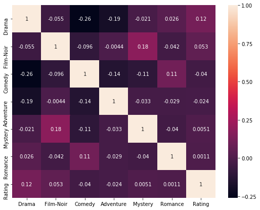

```python
#Finding Correlation between different Genres and Rating:
plt.figure(figsize=(9,7))
sns.heatmap(sample_master_df[['Drama','Film-Noir','Comedy','Adventure','Mystery','Romance','Rating']].corr(),annot=True)
plt.show()
```

```python
#Selected Feature from the above heatmap: [Comedy,Adventure,Romance,Drama]
```

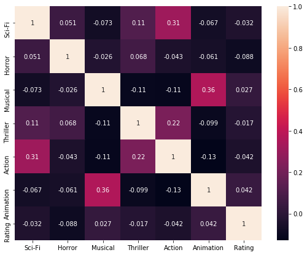

```python
plt.figure(figsize=(9,7))
sns.heatmap(sample_master_df[['Sci-Fi','Horror','Musical','Thriller','Action','Animation','Rating']].corr(),annot=True)
plt.show()
```

```python
#Selected Feature from the above Heatmap:[Sci-Fi,Horror,Thriller,Action]
```

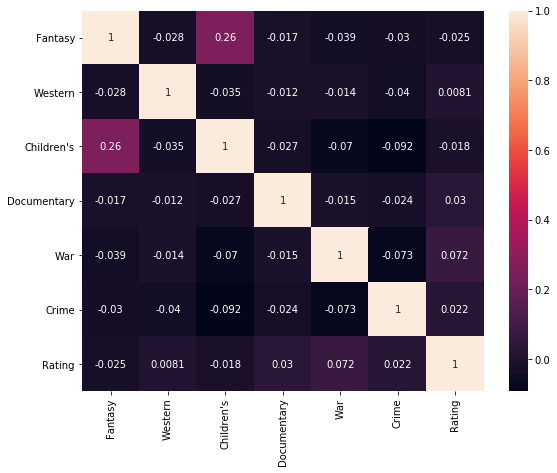

```python
plt.figure(figsize=(9,7))
sns.heatmap(sample_master_df[['Fantasy', 'Western', 'Children\'s','Documentary', 'War', 'Crime','Rating']].corr(),annot=True)
plt.show()
```

```python
#Selected Features from the above heatmap:[Fantasy,Children\'s]
```

```python
#Total selected features from Genres columns:
#total_genres_columns [Comedy,Adventure,Romance,Drama,Sci-Fi,Horror,Thriller,Action,Fantasy,Children\'s]
```

```python
sample_master_df.columns
```

```
Index(['MovieID', 'Title', 'UserID', 'Rating', 'Timestamp', 'Gender', 'Age',
       'Occupation', 'Zip-code', 'Drama', 'Film-Noir', 'Comedy', 'Adventure',
       'Mystery', 'Romance', 'Sci-Fi', 'Horror', 'Musical', 'Thriller',
       'Action', 'Animation', 'Fantasy', 'Western', 'Children's',
       'Documentary', 'War', 'Crime'],
      dtype='object')
```

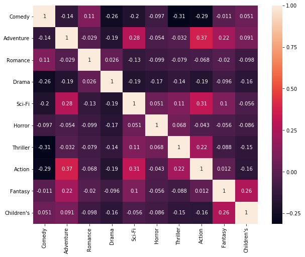

```python
#Finding Correlation between these selected Genres columns:
plt.figure(figsize=(10,8))
sns.heatmap(sample_master_df[['Comedy','Adventure','Romance','Drama','Sci-Fi','Horror','Thriller','Action','Fantasy',
                              'Children\'s']].corr(),annot=True)
plt.show()
```

```python
#[Age,Gender,Occupation,Comedy,Romance]
```

But first we are going to build model **by taking all those features** and check accuracy of the model and then **will drop some of those features** which are prefectly corrleated(either +ve or -ve) and build the model with remaining features.

```python
#Select perticular features and make a list of them:
feature_columns = ['Gender','Age','Occupation','Comedy','Adventure','Romance','Drama',
                   'Sci-Fi','Horror','Thriller','Action','Fantasy','Children\'s']
```

```python
#Check datatype of above columns:
sample_master_df[feature_columns].dtypes
```

```
Gender          int64
Age             int64
Occupation      int64
Comedy        float64
Adventure     float64
Romance       float64
Drama         float64
Sci-Fi        float64
Horror        float64
Thriller      float64
Action        float64
Fantasy       float64
Children's    float64
dtype: object
```

```python
X_features = sample_master_df[feature_columns]
```

```python
X_features.head()
```

|  | Gender | Age | Occupation | Comedy | Adventure | Romance | Drama | Sci-Fi | Horror | Thriller | Action | Fantasy | Children's |
| --- | --- | --- | --- | --- | --- | --- | --- | --- | --- | --- | --- | --- | --- |
| 0 | 0 | 1 | 10 | 1.0 | 0.0 | 0.0 | 0.0 | 0.0 | 0.0 | 0.0 | 0.0 | 0.0 | 1.0 |
| 1 | 0 | 1 | 10 | 0.0 | 0.0 | 1.0 | 0.0 | 0.0 | 0.0 | 0.0 | 0.0 | 0.0 | 1.0 |
| 2 | 0 | 1 | 10 | 0.0 | 0.0 | 0.0 | 1.0 | 0.0 | 0.0 | 0.0 | 0.0 | 0.0 | 0.0 |
| 3 | 0 | 1 | 10 | 0.0 | 1.0 | 0.0 | 0.0 | 1.0 | 0.0 | 0.0 | 1.0 | 1.0 | 0.0 |
| 4 | 0 | 1 | 10 | 0.0 | 0.0 | 0.0 | 1.0 | 0.0 | 0.0 | 0.0 | 0.0 | 0.0 | 0.0 |

```python
X_features['Occupation'].value_counts()
```

```
0     15587
4     13842
17     8900
7      7767
20     6452
1      6448
3      6155
12     5786
16     4991
14     4217
2      3951
10     3495
6      2140
9      1992
11     1920
19     1837
15     1534
8       967
5       947
18      617
13      455
Name: Occupation, dtype: int64
```

```python
#Check Statistics of these selected features:
X_features.describe()
```

|  | Gender | Age | Occupation | Comedy | Adventure | Romance | Drama | Sci-Fi | Horror | Thriller | Action | Fantasy | Children's |
| --- | --- | --- | --- | --- | --- | --- | --- | --- | --- | --- | --- | --- | --- |
| count | 100000.000000 | 100000.000000 | 100000.000000 | 100000.000000 | 100000.00000 | 100000.000000 | 100000.000000 | 100000.000000 | 100000.000000 | 100000.000000 | 100000.000000 | 100000.000000 | 100000.000000 |
| mean | 0.756830 | 27.077170 | 8.054610 | 0.387860 | 0.13493 | 0.151260 | 0.331270 | 0.146730 | 0.071600 | 0.180840 | 0.249170 | 0.038510 | 0.093320 |
| std | 0.428999 | 11.231516 | 6.688251 | 0.487265 | 0.34165 | 0.358304 | 0.470672 | 0.353838 | 0.257826 | 0.384887 | 0.432535 | 0.192425 | 0.290882 |
| min | 0.000000 | 1.000000 | 0.000000 | 0.000000 | 0.00000 | 0.000000 | 0.000000 | 0.000000 | 0.000000 | 0.000000 | 0.000000 | 0.000000 | 0.000000 |
| 25% | 1.000000 | 18.000000 | 2.000000 | 0.000000 | 0.00000 | 0.000000 | 0.000000 | 0.000000 | 0.000000 | 0.000000 | 0.000000 | 0.000000 | 0.000000 |
| 50% | 1.000000 | 25.000000 | 7.000000 | 0.000000 | 0.00000 | 0.000000 | 0.000000 | 0.000000 | 0.000000 | 0.000000 | 0.000000 | 0.000000 | 0.000000 |
| 75% | 1.000000 | 35.000000 | 14.000000 | 1.000000 | 0.00000 | 0.000000 | 1.000000 | 0.000000 | 0.000000 | 0.000000 | 0.000000 | 0.000000 | 0.000000 |
| max | 1.000000 | 56.000000 | 20.000000 | 1.000000 | 1.00000 | 1.000000 | 1.000000 | 1.000000 | 1.000000 | 1.000000 | 1.000000 | 1.000000 | 1.000000 |

### By Observing the above statistics we can see that the columns "Age" and "Occupation" are not on the standard scale with respect to other columns and if we pass this data as it is then our model will become baised towards these two columns as these 2 columns have the higher values than other columns.

### So,to avoid this we are going to perform Normalization on those 2 columns to bring them on Standard Scale(0 to 1)

We are going to use **Min-Max Scalar** for this purpose:

```python
#Import:
from sklearn.preprocessing import MinMaxScaler
```

```python
#Instantiate:
min_max_slr = MinMaxScaler()
```

```python
#Fit and Transform the Data:
X_normalized = min_max_slr.fit_transform(X_features)
```

```python
#View Normalized Data:
X_normalized[:10]
```

```
array([[0. , 0. , 0.5, 1. , 0. , 0. , 0. , 0. , 0. , 0. , 0. , 0. , 1. ],
       [0. , 0. , 0.5, 0. , 0. , 1. , 0. , 0. , 0. , 0. , 0. , 0. , 1. ],
       [0. , 0. , 0.5, 0. , 0. , 0. , 1. , 0. , 0. , 0. , 0. , 0. , 0. ],
       [0. , 0. , 0.5, 0. , 1. , 0. , 0. , 1. , 0. , 0. , 1. , 1. , 0. ],
       [0. , 0. , 0.5, 0. , 0. , 0. , 1. , 0. , 0. , 0. , 0. , 0. , 0. ],
       [0. , 0. , 0.5, 0. , 0. , 0. , 1. , 0. , 0. , 0. , 0. , 0. , 1. ],
       [0. , 0. , 0.5, 1. , 0. , 0. , 0. , 0. , 0. , 0. , 0. , 0. , 1. ],
       [0. , 0. , 0.5, 0. , 0. , 0. , 0. , 0. , 0. , 0. , 0. , 0. , 1. ],
       [0. , 0. , 0.5, 0. , 0. , 0. , 0. , 0. , 0. , 0. , 0. , 0. , 1. ],
       [0. , 0. , 0.5, 0. , 0. , 0. , 1. , 0. , 0. , 1. , 0. , 0. , 0. ]])
```

```python
#Convert it again into dataframe:
X_features_normalized = pd.DataFrame(data=X_normalized,columns=X_features.columns)
```

```python
#View first few records:
X_features_normalized.head()
```

|  | Gender | Age | Occupation | Comedy | Adventure | Romance | Drama | Sci-Fi | Horror | Thriller | Action | Fantasy | Children's |
| --- | --- | --- | --- | --- | --- | --- | --- | --- | --- | --- | --- | --- | --- |
| 0 | 0.0 | 0.0 | 0.5 | 1.0 | 0.0 | 0.0 | 0.0 | 0.0 | 0.0 | 0.0 | 0.0 | 0.0 | 1.0 |
| 1 | 0.0 | 0.0 | 0.5 | 0.0 | 0.0 | 1.0 | 0.0 | 0.0 | 0.0 | 0.0 | 0.0 | 0.0 | 1.0 |
| 2 | 0.0 | 0.0 | 0.5 | 0.0 | 0.0 | 0.0 | 1.0 | 0.0 | 0.0 | 0.0 | 0.0 | 0.0 | 0.0 |
| 3 | 0.0 | 0.0 | 0.5 | 0.0 | 1.0 | 0.0 | 0.0 | 1.0 | 0.0 | 0.0 | 1.0 | 1.0 | 0.0 |
| 4 | 0.0 | 0.0 | 0.5 | 0.0 | 0.0 | 0.0 | 1.0 | 0.0 | 0.0 | 0.0 | 0.0 | 0.0 | 0.0 |

```python
X_features_normalized['Occupation'].value_counts()
```

```
0.00    15587
0.20    13842
0.85     8900
0.35     7767
1.00     6452
0.05     6448
0.15     6155
0.60     5786
0.80     4991
0.70     4217
0.10     3951
0.50     3495
0.30     2140
0.45     1992
0.55     1920
0.95     1837
0.75     1534
0.40      967
0.25      947
0.90      617
0.65      455
Name: Occupation, dtype: int64
```

```python
#View Statisctics again:
X_features_normalized.describe()
```

|  | Gender | Age | Occupation | Comedy | Adventure | Romance | Drama | Sci-Fi | Horror | Thriller | Action | Fantasy | Children's |
| --- | --- | --- | --- | --- | --- | --- | --- | --- | --- | --- | --- | --- | --- |
| count | 100000.000000 | 100000.000000 | 100000.000000 | 100000.000000 | 100000.00000 | 100000.000000 | 100000.000000 | 100000.000000 | 100000.000000 | 100000.000000 | 100000.000000 | 100000.000000 | 100000.000000 |
| mean | 0.756830 | 0.474130 | 0.402731 | 0.387860 | 0.13493 | 0.151260 | 0.331270 | 0.146730 | 0.071600 | 0.180840 | 0.249170 | 0.038510 | 0.093320 |
| std | 0.428999 | 0.204209 | 0.334413 | 0.487265 | 0.34165 | 0.358304 | 0.470672 | 0.353838 | 0.257826 | 0.384887 | 0.432535 | 0.192425 | 0.290882 |
| min | 0.000000 | 0.000000 | 0.000000 | 0.000000 | 0.00000 | 0.000000 | 0.000000 | 0.000000 | 0.000000 | 0.000000 | 0.000000 | 0.000000 | 0.000000 |
| 25% | 1.000000 | 0.309091 | 0.100000 | 0.000000 | 0.00000 | 0.000000 | 0.000000 | 0.000000 | 0.000000 | 0.000000 | 0.000000 | 0.000000 | 0.000000 |
| 50% | 1.000000 | 0.436364 | 0.350000 | 0.000000 | 0.00000 | 0.000000 | 0.000000 | 0.000000 | 0.000000 | 0.000000 | 0.000000 | 0.000000 | 0.000000 |
| 75% | 1.000000 | 0.618182 | 0.700000 | 1.000000 | 0.00000 | 0.000000 | 1.000000 | 0.000000 | 0.000000 | 0.000000 | 0.000000 | 0.000000 | 0.000000 |
| max | 1.000000 | 1.000000 | 1.000000 | 1.000000 | 1.00000 | 1.000000 | 1.000000 | 1.000000 | 1.000000 | 1.000000 | 1.000000 | 1.000000 | 1.000000 |

```python
#View info of the Normalized dataframe:
X_features_normalized.info()
```

```
<class 'pandas.core.frame.DataFrame'>
RangeIndex: 100000 entries, 0 to 99999
Data columns (total 13 columns):
Gender        100000 non-null float64
Age           100000 non-null float64
Occupation    100000 non-null float64
Comedy        100000 non-null float64
Adventure     100000 non-null float64
Romance       100000 non-null float64
Drama         100000 non-null float64
Sci-Fi        100000 non-null float64
Horror        100000 non-null float64
Thriller      100000 non-null float64
Action        100000 non-null float64
Fantasy       100000 non-null float64
Children's    100000 non-null float64
dtypes: float64(13)
memory usage: 9.9 MB
```

```python
#Separate Target variable:
y = sample_master_df.Rating
```

```python
#Check type:
type(y)
```

```
pandas.core.series.Series
```

```python
#Check Size:
y.size
```

```
100000
```

```python
#Print first and last few records:
y[:5]
```

```
0    5
1    5
2    5
3    4
4    5
Name: Rating, dtype: int64
```

```python
y[99995:]
```

```
99995    1
99996    3
99997    4
99998    2
99999    1
Name: Rating, dtype: int64
```

Select first 25,000 records for model building.

Performing **train-test** split:

```python
X_features_normalized_sample = X_features_normalized[:25000]
```

```python
y_sample = y[:25000]
```

### Performing Train-Test Split:

```python
from sklearn.model_selection import train_test_split
```

```python
#Perform train-test split:
X_train,X_test,y_train,y_test = train_test_split(X_features_normalized_sample,y_sample,test_size=0.5,random_state=22)
```

```python
#Check Shape of the each Dataset:
print("X_train: {}".format(X_train.shape))
print("X_test:  {}".format(X_test.shape))
print("y_train: {}".format(y_train.shape))
print("y_test:  {}".format(y_test.shape))
```

```
X_train: (12500, 13)
X_test:  (12500, 13)
y_train: (12500,)
y_test:  (12500,)
```

### Model Building using DecisionTreeClassifier:

```python
#Import:
from sklearn.tree import DecisionTreeClassifier
```

```python
#Instatiate:
dt_classifier_model_v1 = DecisionTreeClassifier()
```

```python
#Fit:
print("Training Model--")
dt_classifier_model_v1.fit(X_train,y_train)
```

```
Training Model--
```

```
DecisionTreeClassifier(class_weight=None, criterion='gini', max_depth=None,
            max_features=None, max_leaf_nodes=None,
            min_impurity_decrease=0.0, min_impurity_split=None,
            min_samples_leaf=1, min_samples_split=2,
            min_weight_fraction_leaf=0.0, presort=False, random_state=None,
            splitter='best')
```

```python
#Test Trained Model on Test dataset:
y_predicted_v1 = dt_classifier_model_v1.predict(X_test)
```

```python
#Check Accuracy of the Model:
#Let's import Accuracy Score,Confusion Matrix:
from sklearn.metrics import accuracy_score
from sklearn.metrics import confusion_matrix
```

```python
print("FINISHED classifying. accuracy score :")
print(accuracy_score(y_test,y_predicted_v1))
```

```
FINISHED classifying. accuracy score :
0.33776
```

By observing the above accuracy score we can clearly say that our Model is **not Trained well** or we can say that it is **underfitted**.

### Let's perform some experimentation to improve this accuracy score:

#### Exp-1: Train-Test split with 70:30 ratio(previous was 50:50)

```python
X_train,X_test,y_train,y_test = train_test_split(X_features_normalized_sample,y_sample,test_size=.3,random_state=22)
```

```python
#Check shape of the each dataset:
print("X_train: {}".format(X_train.shape))
print("X_test:  {}".format(X_test.shape))
print("y_train: {}".format(y_train.shape))
print("y_test:  {}".format(y_test.shape))
```

```
X_train: (17500, 13)
X_test:  (7500, 13)
y_train: (17500,)
y_test:  (7500,)
```

```python
#Instatiate:
dt_classifier_model_v2 = DecisionTreeClassifier()
```

```python
#Fit:
print("Training Model:")
dt_classifier_model_v2.fit(X_train,y_train)
```

```
Training Model:
```

```
DecisionTreeClassifier(class_weight=None, criterion='gini', max_depth=None,
            max_features=None, max_leaf_nodes=None,
            min_impurity_decrease=0.0, min_impurity_split=None,
            min_samples_leaf=1, min_samples_split=2,
            min_weight_fraction_leaf=0.0, presort=False, random_state=None,
            splitter='best')
```

```python
#Test this Trained Improved Model on Test Data:
y_predicted_v2 = dt_classifier_model_v2.predict(X_test)
```

```python
#Check Accuracy again:
print("FINISHED classifying. accuracy score :")
print(accuracy_score(y_test,y_predicted_v2))
```

```
FINISHED classifying. accuracy score :
0.3436
```

#### Exp-2: Changing Criterian = 'entropy':

```python
#Check shape of the each dataset:
print("X_train: {}".format(X_train.shape))
print("X_test:  {}".format(X_test.shape))
print("y_train: {}".format(y_train.shape))
print("y_test:  {}".format(y_test.shape))
```

```
X_train: (17500, 13)
X_test:  (7500, 13)
y_train: (17500,)
y_test:  (7500,)
```

```python
#Instantiate:
dt_classifier_model_v3 = DecisionTreeClassifier(criterion='entropy')
```

```python
#Fit:
print("Training Model:")
dt_classifier_model_v3.fit(X_train,y_train)
```

```
Training Model:
```

```
DecisionTreeClassifier(class_weight=None, criterion='entropy', max_depth=None,
            max_features=None, max_leaf_nodes=None,
            min_impurity_decrease=0.0, min_impurity_split=None,
            min_samples_leaf=1, min_samples_split=2,
            min_weight_fraction_leaf=0.0, presort=False, random_state=None,
            splitter='best')
```

```python
#Test this Trained Improved Model on Test Data:
y_predicted_v3 = dt_classifier_model_v3.predict(X_test)
```

```python
#Checking Accuracy again:
print("FINISHED classifying. accuracy score :")
print(accuracy_score(y_test,y_predicted_v3))
```

```
FINISHED classifying. accuracy score :
0.3449333333333333
```

#### Exp-3: Making min_samples_split=5(default 2) and criterian='entropy'

```python
#Check shape of the each dataset:
print("X_train: {}".format(X_train.shape))
print("X_test:  {}".format(X_test.shape))
print("y_train: {}".format(y_train.shape))
print("y_test:  {}".format(y_test.shape))
```

```
X_train: (17500, 13)
X_test:  (7500, 13)
y_train: (17500,)
y_test:  (7500,)
```

```python
#Instatiate:
dt_classifier_model_v4 = DecisionTreeClassifier(criterion='entropy',min_samples_split=5)
```

```python
#Fit:
print("Training Model:")
dt_classifier_model_v4.fit(X_train,y_train)
```

```
Training Model:
```

```
DecisionTreeClassifier(class_weight=None, criterion='entropy', max_depth=None,
            max_features=None, max_leaf_nodes=None,
            min_impurity_decrease=0.0, min_impurity_split=None,
            min_samples_leaf=1, min_samples_split=5,
            min_weight_fraction_leaf=0.0, presort=False, random_state=None,
            splitter='best')
```

```python
#Test this Trained Improved Model on Test Data:
y_predicted_v4 = dt_classifier_model_v4.predict(X_test)
```

```python
#Check Accuracy again:
print("FINISHED classifying. accuracy score :")
print(accuracy_score(y_test,y_predicted_v4))
```

```
FINISHED classifying. accuracy score :
0.3453333333333333
```

#### Exp-4: Making min_samples_split=10(default 2) and criterian='entropy'

```python
#Instantiate:
dt_classifier_model_v5 = DecisionTreeClassifier(criterion='entropy',min_samples_split=10)
```

```python
#Fit:
print("Training Model:")
dt_classifier_model_v5.fit(X_train,y_train)
```

```
Training Model:
```

```
DecisionTreeClassifier(class_weight=None, criterion='entropy', max_depth=None,
            max_features=None, max_leaf_nodes=None,
            min_impurity_decrease=0.0, min_impurity_split=None,
            min_samples_leaf=1, min_samples_split=10,
            min_weight_fraction_leaf=0.0, presort=False, random_state=None,
            splitter='best')
```

```python
#Test this Trained Improved Model on Test Data:
y_predicted_v5 = dt_classifier_model_v5.predict(X_test)
```

```python
#Check Accuracy again:
print("FINISHED classifying. accuracy score :")
print(accuracy_score(y_test,y_predicted_v5))
```

```
FINISHED classifying. accuracy score :
0.3466666666666667
```

### REMARK:

*WE HAVE SEEN THAT BY TUNING SOME PARAMETERS WE HAVE SLIGHTLY MADE AN IMPROVEMENT IN OUR ACCURACY. BUT STILL THIS ACCURACY IS VERY LESS(BAD)WHEN CONSIDERED MODEL TO DEPLOY. SO,WE CAN'T USE THIS MODEL FOR PRODUCTION.*

WE ARE GOING TO SOLVE THIS PROBLEM USING DEFFERENT CLASSIFIER WHICH IS **"RANDOM FORREST".**

### Model building using "Random forrest Classifier":

```python
#View the Train and Test datasets:
print("X_train: {}".format(X_train.shape))
print("X_test:  {}".format(X_test.shape))
print("y_train: {}".format(y_train.shape))
print("y_test:  {}".format(y_test.shape))
```

```
X_train: (17500, 13)
X_test:  (7500, 13)
y_train: (17500,)
y_test:  (7500,)
```

```python
#Import:
from sklearn.ensemble import RandomForestClassifier
```

```python
#Instantiate:
model_random_forrest_v1 = RandomForestClassifier()
```

```python
#Fit:
print("Training of the Model:")
model_random_forrest_v1.fit(X_train,y_train)
```

```
Training of the Model:
```

```
RandomForestClassifier(bootstrap=True, class_weight=None, criterion='gini',
            max_depth=None, max_features='auto', max_leaf_nodes=None,
            min_impurity_decrease=0.0, min_impurity_split=None,
            min_samples_leaf=1, min_samples_split=2,
            min_weight_fraction_leaf=0.0, n_estimators=10, n_jobs=None,
            oob_score=False, random_state=None, verbose=0,
            warm_start=False)
```

```python
#Test the trained model on Test dataset:
y_pred_rf_v1 = model_random_forrest_v1.predict(X_test)
```

```python
#View the accuracy:
print("FINISHED classifying. accuracy score :")
print(accuracy_score(y_test,y_pred_rf_v1))
```

```
FINISHED classifying. accuracy score :
0.348
```

#### Changing criterian='entropy':

```python
#Instantiate with criterian--entropy
model_random_forrest_v2 = RandomForestClassifier(criterion='entropy',n_estimators=100)
```

```python
#Fit:
print("Training the model:")
model_random_forrest_v2.fit(X_train,y_train)
```

```
Training the model:
```

```
RandomForestClassifier(bootstrap=True, class_weight=None, criterion='entropy',
            max_depth=None, max_features='auto', max_leaf_nodes=None,
            min_impurity_decrease=0.0, min_impurity_split=None,
            min_samples_leaf=1, min_samples_split=2,
            min_weight_fraction_leaf=0.0, n_estimators=100, n_jobs=None,
            oob_score=False, random_state=None, verbose=0,
            warm_start=False)
```

```python
#Prediction on Test Data:
y_pred_rf_v2 = model_random_forrest_v2.predict(X_test)
```

```python
#Check Accuracy:
print("FINISHED classifying. accuracy score :")
print(accuracy_score(y_test,y_pred_rf_v2))
```

```
FINISHED classifying. accuracy score :
0.3509333333333333
```

```python
#View Confusion Matrix:
print("FINISHED classifying.Confusion matrix:")
print(confusion_matrix(y_test,y_pred_rf_v2))
```

```
FINISHED classifying.Confusion matrix:
[[  52   48  136  181   57]
 [  24   70  266  376   98]
 [  31  110  571  942  266]
 [  30   73  570 1425  525]
 [  19   43  279  794  514]]
```

### REMARK:

We have seen that by changing Classifier we are getting slightly better accuracy.

### JUST EXPERIMENT:

USING LOGISTIC_REGRESSION CLASSIFIER WITH PARAMETER **multi_class**:

```python
from sklearn.linear_model import LogisticRegression
```

```python
log_reg = LogisticRegression(multi_class='auto',solver='lbfgs')
```

```python
log_reg.fit(X_train,y_train)
```

```
LogisticRegression(C=1.0, class_weight=None, dual=False, fit_intercept=True,
          intercept_scaling=1, max_iter=100, multi_class='auto',
          n_jobs=None, penalty='l2', random_state=None, solver='lbfgs',
          tol=0.0001, verbose=0, warm_start=False)
```

```python
y_predict_logReg = log_reg.predict(X_test)
```

```python
print(accuracy_score(y_test,y_predict_logReg))
```

```
0.34453333333333336
```

### REMARK:

NO ANY CHANGE IN THE ACCURACY.

### FEATURE ENGINNERING: DROPPING SOME OF THE FEATURES--

```python
X_features_normalized_sample.head()
```

|  | Gender | Age | Occupation | Comedy | Adventure | Romance | Drama | Sci-Fi | Horror | Thriller | Action | Fantasy | Children's |
| --- | --- | --- | --- | --- | --- | --- | --- | --- | --- | --- | --- | --- | --- |
| 0 | 0.0 | 0.0 | 0.5 | 1.0 | 0.0 | 0.0 | 0.0 | 0.0 | 0.0 | 0.0 | 0.0 | 0.0 | 1.0 |
| 1 | 0.0 | 0.0 | 0.5 | 0.0 | 0.0 | 1.0 | 0.0 | 0.0 | 0.0 | 0.0 | 0.0 | 0.0 | 1.0 |
| 2 | 0.0 | 0.0 | 0.5 | 0.0 | 0.0 | 0.0 | 1.0 | 0.0 | 0.0 | 0.0 | 0.0 | 0.0 | 0.0 |
| 3 | 0.0 | 0.0 | 0.5 | 0.0 | 1.0 | 0.0 | 0.0 | 1.0 | 0.0 | 0.0 | 1.0 | 1.0 | 0.0 |
| 4 | 0.0 | 0.0 | 0.5 | 0.0 | 0.0 | 0.0 | 1.0 | 0.0 | 0.0 | 0.0 | 0.0 | 0.0 | 0.0 |

```python
X_features_normalized_sample.info()
```

```
<class 'pandas.core.frame.DataFrame'>
RangeIndex: 25000 entries, 0 to 24999
Data columns (total 13 columns):
Gender        25000 non-null float64
Age           25000 non-null float64
Occupation    25000 non-null float64
Comedy        25000 non-null float64
Adventure     25000 non-null float64
Romance       25000 non-null float64
Drama         25000 non-null float64
Sci-Fi        25000 non-null float64
Horror        25000 non-null float64
Thriller      25000 non-null float64
Action        25000 non-null float64
Fantasy       25000 non-null float64
Children's    25000 non-null float64
dtypes: float64(13)
memory usage: 2.5 MB
```

### BUILDING MODEL WITH COLUMNS:

**[AGE,GENDER,OCCUPATION]**

```python
X_features_new = X_features_normalized_sample[['Gender','Age','Occupation']]
```

```python
X_features_new.shape
```

```
(25000, 3)
```

```python
y_sample.shape
```

```
(25000,)
```

```python
#Perform Train-Test split:
X_train_new,X_test_new,y_train_new,y_test_new = train_test_split(X_features_new,y_sample,random_state=22)
```

```python
print("X_train_new: {}".format(X_train_new.shape))
print("X_test_new:  {}".format(X_test_new.shape))
print("y_train_new: {}".format(y_train_new.shape))
print("y_test_new:  {}".format(y_test_new.shape))
```

```
X_train_new: (18750, 3)
X_test_new:  (6250, 3)
y_train_new: (18750,)
y_test_new:  (6250,)
```

### Using Random Forrest Classifier(with criterian='entropy' and n_estimators=100):

```python
model_random_forrest_new = RandomForestClassifier(criterion='entropy',n_estimators=100)
```

```python
model_random_forrest_new.fit(X_train_new,y_train_new)
```

```
RandomForestClassifier(bootstrap=True, class_weight=None, criterion='entropy',
            max_depth=None, max_features='auto', max_leaf_nodes=None,
            min_impurity_decrease=0.0, min_impurity_split=None,
            min_samples_leaf=1, min_samples_split=2,
            min_weight_fraction_leaf=0.0, n_estimators=100, n_jobs=None,
            oob_score=False, random_state=None, verbose=0,
            warm_start=False)
```

```python
y_pred_rf_new = model_random_forrest_new.predict(X_test_new)
```

```python
#Check Accuracy:
print("FINISHED classifying. accuracy score :")
print(accuracy_score(y_test_new,y_pred_rf_new))
```

```
FINISHED classifying. accuracy score :
0.36112
```

```python
X_features_new = X_features_normalized_sample[['Age','Gender','Occupation','Comedy','Romance']]
```

```python
X_features_new.head()
```

|  | Age | Gender | Occupation | Comedy | Romance |
| --- | --- | --- | --- | --- | --- |
| 0 | 0.0 | 0.0 | 0.5 | 1.0 | 0.0 |
| 1 | 0.0 | 0.0 | 0.5 | 0.0 | 1.0 |
| 2 | 0.0 | 0.0 | 0.5 | 0.0 | 0.0 |
| 3 | 0.0 | 0.0 | 0.5 | 0.0 | 0.0 |
| 4 | 0.0 | 0.0 | 0.5 | 0.0 | 0.0 |

```python
X_features_new.shape
```

```
(25000, 5)
```

```python
#Perform Train-Test split:
X_train_new,X_test_new,y_train_new,y_test_new = train_test_split(X_features_new,y_sample,random_state=22)
```

```python
print("X_train_new: {}".format(X_train_new.shape))
print("X_test_new:  {}".format(X_test_new.shape))
print("y_train_new: {}".format(y_train_new.shape))
print("y_test_new:  {}".format(y_test_new.shape))
```

```
X_train_new: (18750, 5)
X_test_new:  (6250, 5)
y_train_new: (18750,)
y_test_new:  (6250,)
```

```python
model_random_forrest_new = RandomForestClassifier(criterion='entropy',n_estimators=100)
```

```python
model_random_forrest_new.fit(X_train_new,y_train_new)
```

```
RandomForestClassifier(bootstrap=True, class_weight=None, criterion='entropy',
            max_depth=None, max_features='auto', max_leaf_nodes=None,
            min_impurity_decrease=0.0, min_impurity_split=None,
            min_samples_leaf=1, min_samples_split=2,
            min_weight_fraction_leaf=0.0, n_estimators=100, n_jobs=None,
            oob_score=False, random_state=None, verbose=0,
            warm_start=False)
```

```python
y_pred_rf_new = model_random_forrest_new.predict(X_test_new)
```

```python
print("FINISHED classifying. accuracy score :")
print(accuracy_score(y_test_new,y_pred_rf_new))
```

```
FINISHED classifying. accuracy score :
0.36048
```